# EDA-covid

If you think the below information is helpful please UPVOTE.

Your UPVOTES keeps me boosting up to provide more insights, THANK YOU

Coronavirus disease 2019 (COVID-19) is an infectious disease caused by severe acute respiratory syndrome coronavirus 2 (SARS-CoV-2).The disease was first identified in December 2019 in Wuhan, the capital of China's Hubei province, and has since spread globally, resulting in the ongoing 2019–20 coronavirus pandemic. Common symptoms include fever, cough, and shortness of breath Other symptoms may include muscle pain, sputum production, diarrhea, sore throat, loss of smell, and abdominal pain. While the majority of cases result in mild symptoms, some progress to viral pneumonia and multi-organ failure. As of 3 April 2020, more than 1.03 million cases of COVID-19 have been reported in more than two hundred countries and territories, resulting in over 55 thousand deaths. More than 219 thousand people have recovered.

[figure not shown]

```python
from IPython.display import Image
Image(filename='c-1.jpg')
```

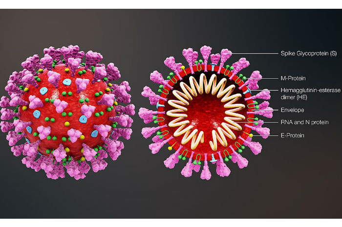

```python
from IPython.display import Image
Image(filename='c-2.jpg')
```

Preventive measures to reduce the chances of infection include staying at home, avoiding crowded places, washing hands with soap and water often and for at least 20 seconds, practicing good respiratory hygiene and avoiding touching the eyes, nose, or mouth with unwashed hands.

```python
from IPython.display import Video
Video("Covid-19-Transmission-graphic-01.gif")
```

[video not shown]

Imports and Datasets

Pandas - for dataset handeling Numpy - Support for Pandas and calculations Matplotlib - for visualization (Platting graphas) plotly - for interative plots

```python
import seaborn as sns
import pandas as pd
import numpy as np
import matplotlib.pyplot as plt
import warnings
warnings.filterwarnings('ignore')
import os
```

About this file

Number of covid-19 cases in India at daily leve

Context

Coronaviruses are a large family of viruses which may cause illness in animals or humans. In humans, several coronaviruses are known to cause respiratory infections ranging from the common cold to more severe diseases such as Middle East Respiratory Syndrome (MERS) and Severe Acute Respiratory Syndrome (SARS). The most recently discovered coronavirus causes coronavirus disease COVID-19 - World Health Organization

The number of new cases are increasing day by day around the world. This dataset has information from the states and union territories of India at daily level.

State level data comes from Ministry of Health & Family Welfare

Individual level data comes from covid19india

Content

COVID-19 cases at daily level is present in covid_19_india.csv file

Individual level details are present in IndividualDetails.csv file and is obtained from this link

Population at state level is present in population_india_census2011.csv file

Number of COVID-19 tests at daily level in ICMRTestingDetails.csv file

Number of hospital beds in each state in present in HospitalBedsIndia.csv file and is extracted from this link

Travel history dataset by @dheerajmpai - https://www.kaggle.com/dheerajmpai/covidindiatravelhistory

Acknowledgements

Thanks to Indian Ministry of Health & Family Welfare for making the data available to general public.

Thanks to covid19india.org for making the individual level details and testing details available to general public.

Thanks to Wikipedia for population information.

Photo Courtesy - https://hgis.uw.edu/virus/

Inspiration

Looking for data based suggestions to stop / delay the spread of virus

```python
covid=pd.read_csv('covid_19_india.csv')
covid.head()
```

|  | Sno | Date | Time | State/UnionTerritory | ConfirmedIndianNational | ConfirmedForeignNational | Cured | Deaths | Confirmed |
| --- | --- | --- | --- | --- | --- | --- | --- | --- | --- |
| 0 | 1 | 30/01/20 | 6:00 PM | Kerala | 1 | 0 | 0 | 0 | 1 |
| 1 | 2 | 31/01/20 | 6:00 PM | Kerala | 1 | 0 | 0 | 0 | 1 |
| 2 | 3 | 01/02/20 | 6:00 PM | Kerala | 2 | 0 | 0 | 0 | 2 |
| 3 | 4 | 02/02/20 | 6:00 PM | Kerala | 3 | 0 | 0 | 0 | 3 |
| 4 | 5 | 03/02/20 | 6:00 PM | Kerala | 3 | 0 | 0 | 0 | 3 |

The above uploaded dataset consists of data which gives information about the corona virus spread, and the datset contains columns like

```
serial number----> which shows the count of numbers
Date ------------>the date when the cases got registered / Date of observation
Time ------------> the time when the cases are filed / Time of observation
State/UnionTerritory--> Name of the State / Union territory
ConfirmedIndianNational--> Cumulative number of confirmed Indian nationals
ConfirmedForeignNational---> Cumulative number of confirmed foreign nationals
Cured--------> Cumulative number of cured people
Deaths-------> Cumulative number of death cases
Confirmed------> Cumulative number of confirmed cases
```

```python
covid.shape
```

```
(587, 9)
```

```python
covid.info()
```

```
<class 'pandas.core.frame.DataFrame'>
RangeIndex: 587 entries, 0 to 586
Data columns (total 9 columns):
 #   Column                    Non-Null Count  Dtype
---  ------                    --------------  -----
 0   Sno                       587 non-null    int64
 1   Date                      587 non-null    object
 2   Time                      587 non-null    object
 3   State/UnionTerritory      587 non-null    object
 4   ConfirmedIndianNational   587 non-null    object
 5   ConfirmedForeignNational  587 non-null    object
 6   Cured                     587 non-null    int64
 7   Deaths                    587 non-null    int64
 8   Confirmed                 587 non-null    int64
dtypes: int64(4), object(5)
memory usage: 41.4+ KB
```

```python
covid.columns

# The names of the columns present in the datset
```

```
Index(['Sno', 'Date', 'Time', 'State/UnionTerritory',
       'ConfirmedIndianNational', 'ConfirmedForeignNational', 'Cured',
       'Deaths', 'Confirmed'],
      dtype='object')
```

```python
covid.describe()
```

|  | Sno | Cured | Deaths | Confirmed |
| --- | --- | --- | --- | --- |
| count | 587.00000 | 587.000000 | 587.000000 | 587.000000 |
| mean | 294.00000 | 1.887564 | 0.504259 | 23.301533 |
| std | 169.59658 | 4.771678 | 1.258920 | 42.272148 |
| min | 1.00000 | 0.000000 | 0.000000 | 1.000000 |
| 25% | 147.50000 | 0.000000 | 0.000000 | 2.000000 |
| 50% | 294.00000 | 0.000000 | 0.000000 | 7.000000 |
| 75% | 440.50000 | 1.500000 | 1.000000 | 27.000000 |
| max | 587.00000 | 42.000000 | 13.000000 | 335.000000 |

```python
covid.isnull().sum()
```

```
Sno                         0
Date                        0
Time                        0
State/UnionTerritory        0
ConfirmedIndianNational     0
ConfirmedForeignNational    0
Cured                       0
Deaths                      0
Confirmed                   0
dtype: int64
```

```python
covid= covid.drop(['Sno'],axis=1)
```

```python
covid.head()
```

|  | Date | Time | State/UnionTerritory | ConfirmedIndianNational | ConfirmedForeignNational | Cured | Deaths | Confirmed |
| --- | --- | --- | --- | --- | --- | --- | --- | --- |
| 0 | 30/01/20 | 6:00 PM | Kerala | 1 | 0 | 0 | 0 | 1 |
| 1 | 31/01/20 | 6:00 PM | Kerala | 1 | 0 | 0 | 0 | 1 |
| 2 | 01/02/20 | 6:00 PM | Kerala | 2 | 0 | 0 | 0 | 2 |
| 3 | 02/02/20 | 6:00 PM | Kerala | 3 | 0 | 0 | 0 | 3 |
| 4 | 03/02/20 | 6:00 PM | Kerala | 3 | 0 | 0 | 0 | 3 |

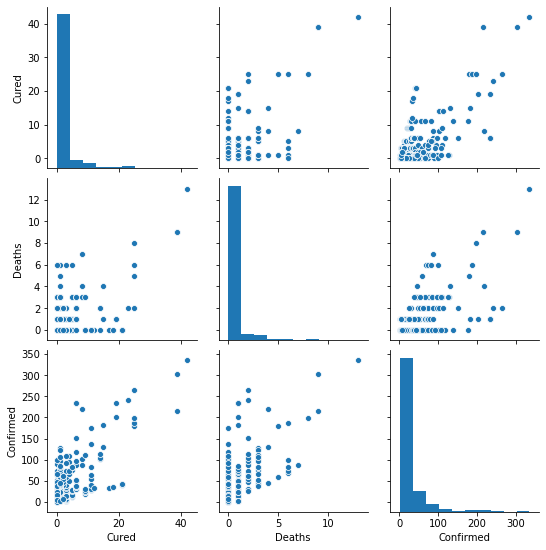

```python
sns.pairplot(covid)
```

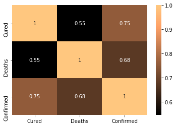

```python
sns.heatmap(covid.corr() , cmap = 'copper' , annot = True)
```

```python
group = covid.groupby('State/UnionTerritory')[ 'Confirmed', 'Cured', 'Deaths'].sum().reset_index()
group
```

|  | State/UnionTerritory | Confirmed | Cured | Deaths |
| --- | --- | --- | --- | --- |
| 0 | Andaman and Nicobar Islands | 56 | 0 | 0 |
| 1 | Andhra Pradesh | 332 | 9 | 1 |
| 2 | Assam | 6 | 0 | 0 |
| 3 | Bihar | 120 | 0 | 12 |
| 4 | Chandigarh | 111 | 0 | 0 |
| 5 | Chattisgarh | 1 | 0 | 0 |
| 6 | Chhattisgarh | 64 | 4 | 0 |
| 7 | Delhi | 967 | 94 | 27 |
| 8 | Goa | 34 | 0 | 0 |
| 9 | Gujarat | 630 | 18 | 43 |
| 10 | Haryana | 572 | 154 | 0 |
| 11 | Himachal Pradesh | 36 | 1 | 10 |
| 12 | Jammu and Kashmir | 352 | 13 | 12 |
| 13 | Jharkhand | 2 | 0 | 0 |
| 14 | Karnataka | 858 | 53 | 34 |
| 15 | Kerala | 2284 | 200 | 7 |
| 16 | Ladakh | 227 | 21 | 0 |
| 17 | Madhya Pradesh | 394 | 0 | 21 |
| 18 | Maharashtra | 2384 | 212 | 71 |
| 19 | Manipur | 10 | 0 | 0 |
| 20 | Mizoram | 9 | 0 | 0 |
| 21 | Odisha | 40 | 0 | 0 |
| 22 | Pondicherry | 2 | 0 | 0 |
| 23 | Puducherry | 18 | 2 | 0 |
| 24 | Punjab | 436 | 6 | 22 |
| 25 | Rajasthan | 820 | 58 | 0 |
| 26 | Tamil Nadu | 822 | 35 | 8 |
| 27 | Telengana | 762 | 19 | 9 |
| 28 | Unassigned | 84 | 0 | 0 |
| 29 | Uttar Pradesh | 943 | 187 | 4 |
| 30 | Uttarakhand | 75 | 10 | 0 |
| 31 | West Bengal | 227 | 12 | 15 |

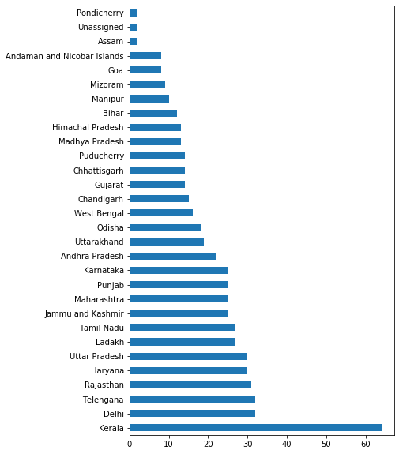

```python
covid['State/UnionTerritory'].value_counts().head(30).plot(kind='barh', figsize=(6,10))
```

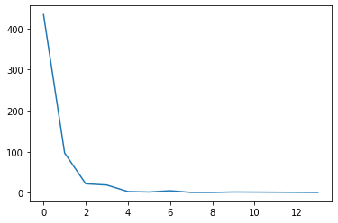

```python
plt.plot(covid['Deaths'].value_counts().sort_index())
```

[figure not shown]

```python
plt.plot(covid['Confirmed'].value_counts().sort_index())
plt.figure(figsize=(15,4))
```

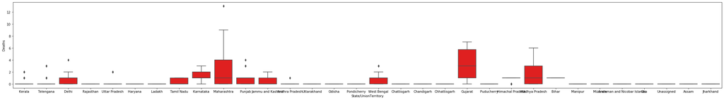

```python
import seaborn as sns
plt.figure(figsize=(40,5))
sns.boxplot(
    data=covid,
    x='State/UnionTerritory',
    y='Deaths',
    color='red')
```

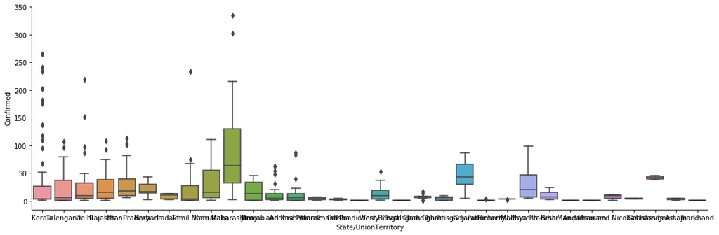

```python
sns.catplot(
    data=covid,
   x='State/UnionTerritory',
    y='Confirmed',
    kind='box',
    height=5,
    aspect=3)
```

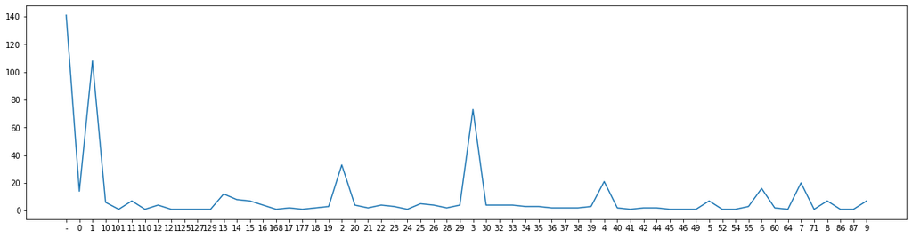

```python
plt.figure(figsize=(20,5))
plt.plot(covid['ConfirmedIndianNational'].value_counts().sort_index())
```

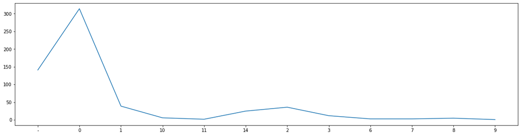

```python
plt.figure(figsize=(20,5))
plt.plot(covid['ConfirmedForeignNational'].value_counts().sort_index())
```